# Probability (Week 3)

Probability is the measure of the likelihood that an event will occur. It is a fundamental concept in mathematics and statistics, and it has many applications in various fields, including science, finance, and gaming.

# 1. Basic Concepts

**Experiment**: A process or action that leads to one or more possible outcomes.

**Sample Space**: The set of all possible outcomes of an experiment.

**Event**: A subset of the sample space that represents the outcome(s) of interest.

Example: Tossing a coin is an experiment with two possible outcomes: heads or tails.

- Sample space: {H, T}
- Event: {H}

**Your turn 1.1:** Write out the sample space and event for following experiments:

1. Tossing a coin twice and getting at least one head.
2. Rolling a six-sided die and getting an odd number.
3. Drawing a card from a standard deck of 52 cards and getting a red card.

# 2. Calculating Probability

Probability is the likelihood or chance of an event occurring. It is calculated by dividing the number of favorable outcomes by the total number of possible outcomes in the sample space.

$$\textbf{Probability}= \frac{\text{Number of Favorable
Outcomes}}{\text{Number of Possible Outcomes}}$$

What is the probability of getting a head when tossing a fair coin?

$\text{Probability of getting a head} = \frac{1}{2} = 0.5$

**Your turn 2.1:** Calculate the probability of the following events:

1. Tossing a coin twice and getting at least one head.
2. Rolling a six-sided die and getting an odd number.
3. Drawing a card from a standard deck of 52 cards and getting a red card.

# 3. Basic Properties of Probability

There are three basic properties of probability that are essential to understand:

1. **Probability is always between 0 and 1**: $0 \leq P(A) \leq 1$
2. **The sum of the probabilities of all possible outcomes is 1**: $P(S) = 1$
3. **The probability of the complement of an event is 1 minus the probability of the event**: $P(A^c) = 1 - P(A)$

# 4. Conditional Probability

Conditional probability is the probability of an event occurring given that another event has already occurred. It is denoted by $P(A|B)$, which reads as “the probability of event A given event B.”

$$Pr(A|B)= \frac{\text{Number of Favorable Outcomes for A and
B}}{\text{Number of Favorable Outcomes for B}}$$

**Example**: What is the probability of getting a head on the second toss given that the first toss was a head?

- Sample Space for tossing a coin twice: {HH, HT, TH, TT}
- Sample Space for the first toss being a head: {HH, HT}
- Event of getting a head on the second toss given the first toss was a head: {HH}

$\text{Probability of getting a head on the second toss given the first toss was a head} = \frac{1}{2} = 0.5$

**Your turn 4.1:** Calculate the conditional probability of the following events:

1. Rolling a six-sided die and getting an odd number given that the number rolled is less than 4.
2. Tossing a coin twice and getting at least one head given that the first toss was a head.
3. Drawing a card from a standard deck of 52 cards and getting a king given that the card drawn is a red.

# 5. Mobile Phone Survey Data

The following packages will be required or may come in handy.

```r
library(tidyverse) # For pipe operator
```

## Data and Variables:

The Mobilephone.csv data are from a [2012 Pew Research Centre Survey](http://www.pewinternet.org/files/old-%20media/Files/Questionnaire/2012/PIP_Just_In_Time_topline.pdf) in the US. The survey asked 2254 respondents numerous questions about their demographics, internet activity and the ways in which they access the internet, including what type of mobile phone they use. We will explore how a user’s residential area (rural, suburban and urban) relates to the probability of owning a smartphone.

The dataset contains 126 variables. There are only two variables we need to consider for this class exercise: **usr** and **SmartPhone** . Coding Information:

**usr**: Residential location of user. Three levels: R: Rural, S: Suburban or U: Urban

Smartphone: Did a respondent own a smartphone? Three levels: 1 = “Cell, smartphone”, 2 = “Cell, not a smartphone”,3 = “No cell”.

Use this dataset to complete the following exercises.

**Your turn 5.1:** Load the data and display the first few rows.

Since we are only interested in the variables **usr** and **SmartPhone**, we can create a subset of the data with only these two variables.

**Your turn 5.2:** Create a subset of the data with only the **usr** and **SmartPhone** variables.

Next we will check if there are any missing values in the **usr** variable. If there are missing values, we will need to handle them before proceeding with the analysis.

```r
# Checking the number of missing values
Mobilephone_filter1$usr%>% is.na() %>%sum()
```

```
[1] 0
```

is.na() returns a logical vector indicating whether each element is missing or not. sum() is used to count the number of missing values. Since the output is 0, does it mean there are no missing values in the **usr** variable? Check if **usr** column has any values that are not R, S or U. (Hint: Use the unique() function)

**Your turn 5.3:** Check if the **usr** column has any values that are not R, S or U.

Now that we have verified that there are blank values in the **usr** column, we will check the percentage of missing/blank values in the **usr** column.

```r
sum(Mobilephone_filter1$usr == ' ')/length(Mobilephone_filter1$usr)
```

```
[1] 0.0390417
```

As a rule of thumb, if you have less than 5% missing values, you can ignore it. We will need to remove the blanks before proceeding with the analysis *(As a rule of thumb, if you have less than 5% missing values, you can ignore them)*. We can do this by creating a subset of the data that only includes the rows where the **usr** column contains only the values R, S, or U.

**Your turn 5.4:** Create a subset of the data that only includes the rows where the **usr** column is not blank and contains only the values R, S, or U.

Now that we have cleaned the data, we can convert both the **usr** and **SmartPhone** variables to factors.

**Your turn 5.5:** Convert the **usr** and **SmartPhone** variables to factors.

Next run the following code to get a table of the counts of the **usr** and **SmartPhone** variables.

```r
# Create a table of the counts of the usr and SmartPhone variables

#option 1
table(Mobilephone_clean1$usr, Mobilephone_clean1$SmartPhone) %>% addmargins()
```

```
           Cell,smartphone Cell,not a smartphone No cell  Sum
  Rural                111                   205      73  389
  Suburban             484                   509     147 1140
  Urban                274                   283      80  637
  Sum                  869                   997     300 2166
```

```r
#option 2
xtabs(~usr + SmartPhone, data = Mobilephone_clean1) %>% addmargins()
```

```
          SmartPhone
usr        Cell,smartphone Cell,not a smartphone No cell  Sum
  Rural                111                   205      73  389
  Suburban             484                   509     147 1140
  Urban                274                   283      80  637
  Sum                  869                   997     300 2166
```

## Probabilities.

We will convert these counts to percentages to find the probabilities of interest.

```r
# Convert the counts to percentages

table(Mobilephone_clean1$usr, Mobilephone_clean1$SmartPhone) %>% prop.table()%>% addmargins()
```

```
           Cell,smartphone Cell,not a smartphone    No cell        Sum
  Rural         0.05124654            0.09464451 0.03370268 0.17959372
  Suburban      0.22345337            0.23499538 0.06786704 0.52631579
  Urban         0.12650046            0.13065559 0.03693444 0.29409049
  Sum           0.40120037            0.46029548 0.13850416 1.00000000
```

**Example**:What’s the probability a person was from a rural area?

#### Using the sample space and event definition

*Event: Individuals from rural areas (389)

#### Using the proportion table

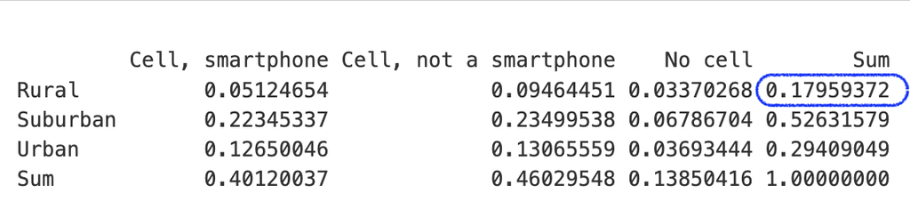

#### Using R code

```r
#Pr(Rural) =
sum(Mobilephone_clean1$usr=="Rural")/length(Mobilephone_clean1$usr)
```

```
[1] 0.1795937
```

**Your turn 5.6:** What’s the probability that a person owned a smartphone?

**Your turn 5.7:** What’s the probability a person had a smartphone and lived in an urban area?

**Your turn 5.8:** What’s the probability a person owned a mobile phone?

## Conditional probabilities.

#### Convert the counts to row proportions

```r
table(Mobilephone_clean1$usr, Mobilephone_clean1$SmartPhone) %>% prop.table(margin=1)%>% addmargins()
```

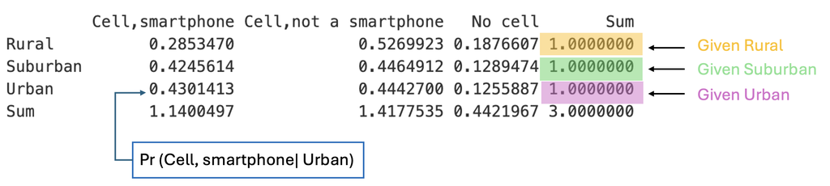

#### Convert the counts to column proportions

```r
table(Mobilephone_clean1$usr, Mobilephone_clean1$SmartPhone) %>% prop.table(margin=2)%>% addmargins()
```

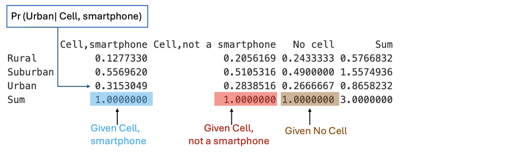

**Example**:What’s the probability a person had a smartphone given they were from a rural area?

#### Using the sample space and event definition

*Sample space: All individuals in the dataset from rural areas (389)

*Event: Individuals from rural areas who owned a smartphone (111)

*Probability = $\frac{111}{389} \approx 0.29$

#### Using the row proportion table

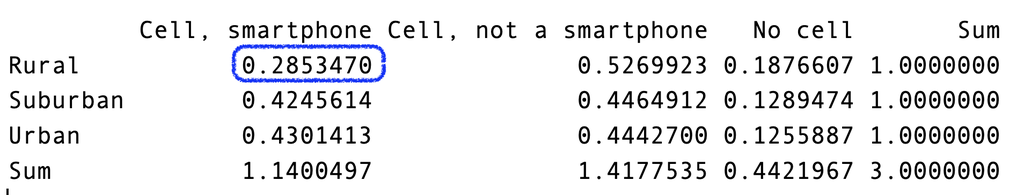

#### Using R code

```r
#Pr(Smartphone|Rural) =
sum(Mobilephone_clean1$usr=="Rural" & Mobilephone_clean1$SmartPhone=="Cell,smartphone")/sum(Mobilephone_clean1$usr=="Rural")
```

```
[1] 0.285347
```

**Your turn 5.9:** What’s the same probability, but for a person who lived in a suburban area?

**Your turn 5.10:** What’s the probability a person lived in an urban area given they owned a smartphone?

## Visualising the data

We will next visualise the smartphone ownership within each area of residence.

```r
table_1 <- table(Mobilephone_clean1$SmartPhone,Mobilephone_clean1$usr) %>%
  prop.table(margin = 2)
table_1 %>% barplot(main = "Smartphone Ownership by Region",
                    ylab="Proportion within Region",
                    ylim=c(0,.8),
                    legend=rownames(table_1), beside=TRUE,
                    args.legend=c(x = "top", horiz=TRUE,
                                  title="Smartphone Ownership"),
                    xlab="Region")
grid()
```

[output not shown]

#### Using ggplot2

```r
df <- as.data.frame(table_1)
colnames(df) <- c('SmartPhone','usr','Prop')

# plot grid and mapping
ggplot(df, aes(fill=SmartPhone, y=Prop, x=usr))+
  geom_bar(position="dodge", stat="identity") +
  labs(title = 'Smartphone Ownership by Region',
       y = 'Proportion within Region',
       x = 'Region', fill='Smartphone Ownership')
```

[output not shown]

**Your turn 5.11:** What do you observe from the bar plot?